# Project 01: Individual Coding & Analysis

STT 2860 Intro to Data Management & Visualization

SOLUTIONS // Jill E. Thomley

Saturday, March 02, 2024 @ 07:22 PM

### Gambling Winnings from *Introduction to R*

In the second chapter of DataCamp’s *Introduction to R* course, you created and manipulated vectors representing winnings for one week in poker and roulette. In some cases you performed operations more than once using different methods, to learn how to be more compact/efficient. You will adapt some of that work here. Be as neat and efficient as you can in your coding.

#### (a) winnings vectors

A person plays poker and roulette on weekdays for two weeks. Winnings (in US dollars) are tabulated below. Negative values are, of course, losses. Create named vectors of winnings for each game where the names are the days of the week.

| Day Number | Day of the Week | Poker Winnings | Roulette Winnings |
| --- | --- | --- | --- |
| 1 | Mon | 140 | -25 |
| 2 | Tue | -50 | -50 |
| 3 | Wed | 20 | 100 |
| 4 | Thu | -120 | -350 |
| 5 | Fri | 240 | 105 |
| 6 | Mon | 100 | 5 |
| 7 | Tue | -30 | -85 |
| 8 | Wed | 305 | 210 |
| 9 | Thu | -90 | 175 |
| 10 | Fri | 1000 | -105 |

```r
# use the rep() function for the pattern

daynames <- c(rep(c("Mon", "Tue", "Wed", "Thu", "Fri"), times = 2))

# create the poker vector from the values

poker <- c(140, -50, 20, -120, 240, 100, -30, 305, -90, 1000)

# assign day names to the values vector

names(poker) <- daynames

# visualize the vector you have created

poker
```

```
 Mon  Tue  Wed  Thu  Fri  Mon  Tue  Wed  Thu  Fri
 140  -50   20 -120  240  100  -30  305  -90 1000
```

```r
# repeat for the roulette winnings vector

roulette <- c(-25, -50, 100, -350, 105, 5, -85, 210, 175, -105)

names(roulette) <- daynames

roulette
```

```
 Mon  Tue  Wed  Thu  Fri  Mon  Tue  Wed  Thu  Fri
 -25  -50  100 -350  105    5  -85  210  175 -105
```

#### (b) daily totals

Combine your vectors from (a) to create one vector that contains the total win/loss amount for each of the 10 days.

```r
daytotals <- poker + roulette

daytotals
```

```
 Mon  Tue  Wed  Thu  Fri  Mon  Tue  Wed  Thu  Fri
 115 -100  120 -470  345  105 -115  515   85  895
```

#### (c) overall totals

Use your vectors from (a) and (b) to find (i) total poker winnings, (ii) total roulette winnings, and (iii) total overall winnings.

```r
poker_winnings <- sum(poker)

poker_winnings
```

```
[1] 1515
```

```r
roulette_winnings <- sum(roulette)

roulette_winnings
```

```
[1] -20
```

```r
# 1st way to get the daily totals

overall_winnings <- sum(daytotals)

overall_winnings
```

```
[1] 1495
```

```r
# 2nd way to get the daily totals

overall_winnings_alt <- poker_winnings + roulette_winnings

overall_winnings_alt
```

```
[1] 1495
```

On which days did the person lose money playing poker? On which days did they lose money playing roulette? What about each day overall? In each of the three cases, select only those days and print them out.

```r
# find which days have negative values (logic vector)
# negative values / losses will be TRUE, others FALSE

index_poker <- poker < 0

index_poker
```

```
  Mon   Tue   Wed   Thu   Fri   Mon   Tue   Wed   Thu   Fri
FALSE  TRUE FALSE  TRUE FALSE FALSE  TRUE FALSE  TRUE FALSE
```

```r
# use the logic vector to select the days with losses
# only days that are TRUE (i.e., 1) will be selected

poker[index_poker]
```

```
 Tue  Thu  Tue  Thu
 -50 -120  -30  -90
```

```r
# alternatively, you can do the selection in one step
# select all vector elements where the values are < 0

poker[poker < 0]
```

```
 Tue  Thu  Tue  Thu
 -50 -120  -30  -90
```

```r
index_roulette <- roulette < 0

roulette[index_roulette]
```

```
 Mon  Tue  Thu  Tue  Fri
 -25  -50 -350  -85 -105
```

```r
index_daytotals <- daytotals < 0

daytotals[index_daytotals]
```

```
 Tue  Thu  Tue
-100 -470 -115
```

#### (e) one weekday

Choose one weekday (Monday through Friday). Create a vector that contains only those two days from the poker winnings vector. Do the same for roulette winnings vector and your vector of daily totals from (b).

```r
# this is similar to the way we found losing days
# however, this situation uses a character vector
# we can use the daynames vector to index the days

index_day <- daynames == "Mon"

# both occurrences of the day we chose will be TRUE

index_day
```

```
 [1]  TRUE FALSE FALSE FALSE FALSE  TRUE FALSE FALSE FALSE FALSE
```

```r
poker[index_day]
```

```
Mon Mon
140 100
```

```r
roulette[index_day]
```

```
Mon Mon
-25   5
```

```r
daytotals[index_day]
```

```
Mon Mon
115 105
```

```r
# alternatively, nest the index in the [] selection

poker[daynames == "Tue"]
```

```
Tue Tue
-50 -30
```

```r
poker[daynames == "Wed"]
```

```
Wed Wed
 20 305
```

```r
poker[daynames == "Thu"]
```

```
 Thu  Thu
-120  -90
```

```r
poker[daynames == "Fri"]
```

```
 Fri  Fri
 240 1000
```

```r
# one other option that combines the previous
# this lets us change one option for all three
# the user only changes the day that they want


daychoice <- "Mon"

poker[daynames == daychoice]
```

```
Mon Mon
140 100
```

```r
roulette[daynames == daychoice]
```

```
Mon Mon
-25   5
```

```r
daytotals[daynames == daychoice]
```

```
Mon Mon
115 105
```

```r
# this version will also work for multiple days
# we use the %in% logical operator instead of ==

daychoice <- c("Mon", "Fri")

poker[daynames %in% daychoice]
```

```
 Mon  Fri  Mon  Fri
 140  240  100 1000
```

```r
roulette[daynames %in% daychoice]
```

```
 Mon  Fri  Mon  Fri
 -25  105    5 -105
```

```r
daytotals[daynames %in% daychoice]
```

```
Mon Fri Mon Fri
115 345 105 895
```

#### (f) wins summary

Does the person tend to make money or lose money playing each game? What about overall? Can you detect any patterns from just the analyses you have done above? What else might help you make sense of these data?

**ANSWER:** During the two weeks that were analyzed, the person had a net win of $1515 at poker and a net loss of $20 at roulette, for an overall net win of $1495. Any other patterns are difficult to detect. Plotting might help.

**An Example Plot**

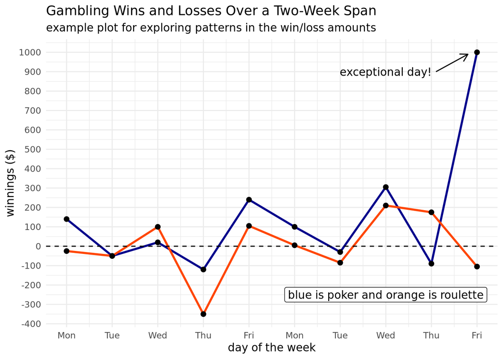

```r
# make a dataset out of your vectors to plot

library(tidyverse)
gambling <- tibble(
  daynumber = 1:10,
  daynames,
  poker,
  roulette,
) %>%
  mutate(daytotal = poker + roulette)

# one possible example of plotting the winnings
# pivoting the data would help create a legend
# I used annotate to identify the lines instead
# pivoting would also cut down on the plot code
# what does each part of the code below create?

ggplot(gambling, aes(x = daynumber)) +
  geom_line(aes(y = poker),
    color = "darkblue",
    size = 1
  ) +
  geom_point(aes(y = poker),
    size = 2
  ) +
  geom_line(aes(y = roulette),
    color = "orangered",
    size = 1
  ) +
  geom_point(aes(y = roulette),
    size = 2
  ) +
  geom_hline(
    yintercept = 0,
    linetype = "dashed"
  ) +
  scale_x_continuous(
    breaks = 1:10,
    labels = daynames
  ) +
  scale_y_continuous(breaks = seq(-1000, 1000, by = 100)) +
  annotate("label",
    x = 8,
    y = -250,
    label = "blue is poker and orange is roulette"
  ) +
  annotate("segment",
    x = 9.1,
    y = 900,
    xend = 9.8,
    yend = 990,
    arrow = arrow(length = unit(.3, "cm"))
  ) +
  annotate("text",
    x = 8,
    y = 900,
    label = "exceptional day!"
  ) +
  labs(
    title = "Gambling Wins and Losses Over a Two-Week Span",
    subtitle = "example plot for exploring patterns in the win/loss amounts",
    x = "day of the week",
    y = "winnings ($)"
  ) +
  theme_minimal()
```